# Acute Heart Failure

December 2019

*Libraries Used*

```r
library('bigrquery')     # Query data from Google BigQuery
library('knitr')         # Make knited tables ("kables")
library('kableExtra')    # Extra kable formatting options
library('ggplot2')       # Plotting library
library('ggpubr')        # More options for ggplot

project = 'socr-mdp-mimic-analytics' # CHANGE THIS TO YOUR PROJECT ID
```

# Introduction

Heart failure (HF) is a “multifactorial, systemic disease” in which a network of autoprotective mechanisms activated after cardiac injury cause significant problems with heart function ([Tanai & Frantz, 2015](https://www.ncbi.nlm.nih.gov/pubmed/26673558)). HF is one of the largest contributing factors to mortality in the United States, playing a role in 1 in 9 deaths and accounting for more than $30 billion in annual healthcare expenditures ([CDC.gov](https://www.cdc.gov/dhdsp/data_statistics/fact_sheets/fs_heart_failure.htm), [Mozaffarian et. al](https://www.ncbi.nlm.nih.gov/pubmed/26673558)). In addition to the estimated 5.7 million Americans living with HF, an additional 915,000 are newly diagnosed each year (Mozaffarian et. al). Despite recent advancements in the treatment of underlying risk factors, long-term mortality remains high with less than half of those newly diagnoses patients suriviving for five years (Mozaffarian et. al).

Risk stratification systems have become an important part of patient management, and have the potential to “improve clinical outcome and resource allocation” by “avoiding the overtreatment of low-risk subjects or the early, inappropriate discharge of high-risk patients” ([Passantino et. al, 2015](https://www.ncbi.nlm.nih.gov/pmc/articles/PMC4691817/)). In their comprehensive 2015 publication, Andrea Passantino and colleagues review a collection of the “most relevant” risk stratification systems targeted at acute heart failure (AHF) including EFFECT, OPTIMIZE-HF, APACHE-HF, and ESCAPE, among others. Passantino and her team describe the wide array of data sources and techniques used by the original authors to validate these scoring systems, including “public registries, clinical trials, and retrospective data” ([Passantino et. al, 2015](https://www.ncbi.nlm.nih.gov/pmc/articles/PMC4691817/)). The heterogeneity of these data sources makes direct performance comparisons difficult.

In this document, we aim to extend the work contributed by Passantino and colleagues and provide a direct comparison of the performance of these AHF risk stratification metrics on a single, unified dataset. To this end, we leverage the Medical Information Mart for Intensive Care ([MIMIC-III](https://mimic.physionet.org/)), a dataset developed by the Massachusetts Institute of Technology Lab for Computational Physiology (MIT-LCP) which contains de-identified health data for more than 40,000 intensive care unit (ICU) patients over the years 2001-2012 ([Johnson et. al, 2012](https://www.ncbi.nlm.nih.gov/pmc/articles/PMC4878278/)). It includes much of the same data commonly found in electronic health records (EHR), including demographic information, diagnosis codes, procedures, laboratory values, vital signs, free-text clinical notes, and admission, discharge, and mortality information. Moreover, it is large and comprehensive enough to serve as a proving ground for each of the individual risk stratification systems, allowing a level playing field from which to make direct comparisons of the efficacy and performance of each proposed metric.

In the spirit of [SOCR’s](http://www.socr.umich.edu) [open science](https://en.wikipedia.org/wiki/Open_science) initiative, this document and it’s parent repository contain the complete end-to-end computational protocol, results, and validation procedures. It is subdivided into the following partitions:

1. *Cohort selection*: criteria for inclusion into the study are codified and explained.
2. *Data extraction*: specific data points are extracted from the larger dataset and transformed for further analysis.
3. *Data manipulation*: extracted data is analyzed and imputed to facilitate scoring.
4. *Scoring*: scoring systems are discussed and applied.
5. *Risk analysis*: the effectiveness of the scoring systems are determined.

# Cohort Selection

As the MIMIC-III dataset contains a wide variety of patients, those suitable for our particular analysis must first be isolated. Based on the manuscripts cited in [Passantino et. al’s review](https://www.ncbi.nlm.nih.gov/pmc/articles/PMC4691817/), we developed a set of inclusion criteria to select such a cohort. These criteria include:

1. Patients diagnosed with acute heart failure, excluding those with existing chronic heart failure.
2. Patients who survived to ICU discharge, prefering to instead focus on out-of-hospital mortality.
3. Patients who stayed in the ICU between 24 hours and 45 days, yielding enough time to facilitate a number of test results while exluding the few ultra-long term ICU stays present in the dataset.
4. Patients who are between 18 and 89 years of age (inclusive).

These criteria were inspired by the inclusion criteria schema described in the following references:

1. [Auble et. al, A Prediction Rule to Identify Low-risk Patients with Heart Failure. *Academic Emergency Medicine*, 2005.](https://onlinelibrary.wiley.com/doi/pdf/10.1197/j.aem.2004.11.026)
2. [Abraham et. al, Predictors of In-Hospital Mortality in Patients Hospitalized for Heart Failure: Insights From the Organized Program to Initiate Lifesaving Treatment in Hospitalized Patients With Heart Failure (OPTIMIZE-HF). *Journal of the Americal College of Cardiology*, 2008.](https://www.sciencedirect.com/science/article/pii/S0735109708016720)
3. [Peterson et. al, A Validated Risk Score for In-Hospital Mortality in Patients With Heart Failure From the American Heart Association Get With the Guidelines Program. *Circulation*, 2009.](https://www.ahajournals.org/doi/pdf/10.1161/CIRCOUTCOMES.109.854877)
4. [Lee et. al, Prediction of Heart Failure Mortality in Emergent Care: A Cohort Study. *Annals of Internal Medicine*, 2012.](https://annals.org/aim/article-abstract/1170879/prediction-heart-failure-mortality-emergent-care-cohort-study)
5. [Okazaki et. al, New scoring system (APACHE-HF) for predicting adverse outcomes in patients with acute heart failure: Evaluation of the APACHE II and Modified APACHE II scoring systems. *Journal of Cardiology*, 2014](https://www.sciencedirect.com/science/article/pii/S0914508714000951?via%3Dihub)
6. [Salah et. al, A novel discharge risk model for patients hospitalised for acute decompensated heart failure incorporating N-terminal pro-B-type natriuretic peptide levels: a European coLlaboration on Acute decompeNsated Heart Failure: ÉLAN-HF Score. *Heart*, 2013](https://heart.bmj.com/content/100/2/115.long)
7. [Lee et. al, Predicting Mortality Among Patients Hospitalized for Heart Failure. *JAMA*, 2003](https://jamanetwork.com/journals/jama/fullarticle/197670)
8. [O’Connor, et. al, Triage After Hospitalization With Advanced Heart Failure: The ESCAPE (Evaluation Study of Congestive Heart Failure and Pulmonary Artery Catheterization Effectiveness) Risk Model and Discharge Score, *Jounral of the American College of Cardiology*, 2010](https://www.sciencedirect.com/science/article/pii/S0735109709040595?via%3Dihub)

## Criteria 1: Patients diagnosed with actue heart failure

To select patients with acute heart failure, we first constructed a cohort of all heart failure patients, denoted by the ICD9 code `4280`, then subtracted those that had an additional chronic heart failure diagnosis (codes `42822, 42823, 42832, 42833, 42842 & 42843`).

```r
sql <- "SELECT *
        FROM [physionet-data.mimiciii_clinical.diagnoses_icd]
        WHERE icd9_code IN ('4280')
        AND hadm_id NOT IN (
            SELECT hadm_id
            FROM [physionet-data.mimiciii_clinical.diagnoses_icd]
            WHERE icd9_code IN ('42822', '42823', '42832', '42833', '42842', '42843')
            GROUP BY hadm_id
        )"

cohort <- query_exec(sql, project=project)
```

Based on this initial query, there are 8059 unique encounters in our cohort representing 6838 individual subjects.

## Criteria 2: Subject survived to ICU discharge

As our target is predicting out-of-hospital mortality due to acute heart failure, we excude patients who expired in the hospital.

```r
# Retrieve PATIENTS table
patients.tbl <- query_exec(
  sprintf( "SELECT SUBJECT_ID, GENDER, DOB, DOD, DOD_HOSP, DOD_SSN
            FROM [physionet-data.mimiciii_clinical.patients]
            WHERE subject_id IN (%s)",
          paste(cohort$SUBJECT_ID, collapse=", ")),
  project=project, max_pages = Inf)

# Merge with cohort object
cohort <- merge(cohort, patients.tbl, by='SUBJECT_ID')

# Remove subjects with an in-hospital date of death
cohort <- cohort[is.na(cohort$DOD_HOSP), ]
```

After removing subjects who did not survive to ICU discharge, we are left with 4603 unique encounters representing 4057 individual subjects.

## Criteria 3: Length of stay between 24-hours and 45 days

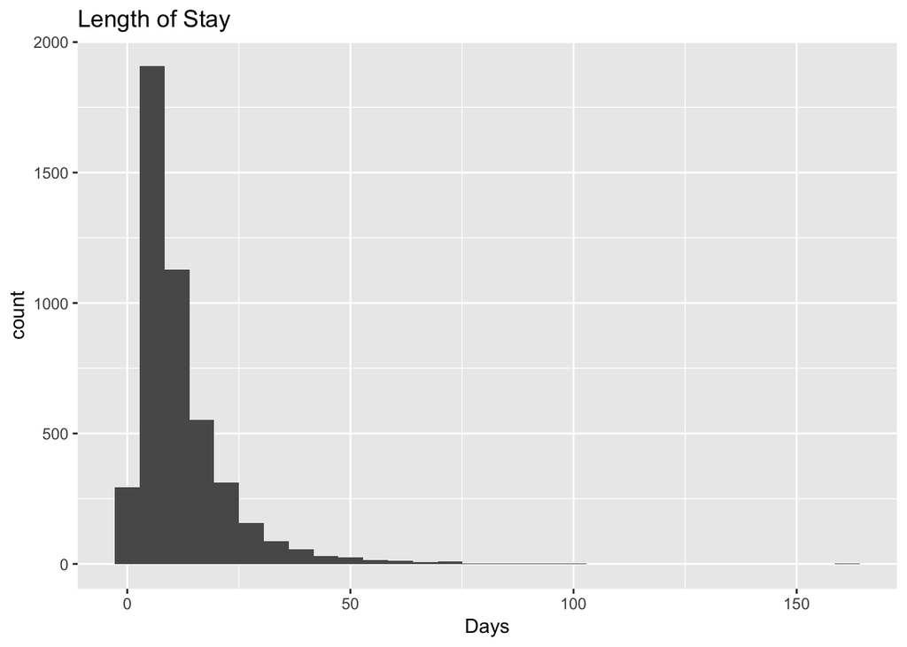

```r
# Get admissions table object
admissions.tbl <- query_exec(
  sprintf( "SELECT *
            FROM [physionet-data.mimiciii_clinical.admissions]
            WHERE hadm_id IN (%s)",
          paste(cohort$HADM_ID, collapse=", ")),
  project=project, max_pages = Inf)

# Calculate length of stay
admissions.tbl$LOS <- difftime(admissions.tbl$DISCHTIME, admissions.tbl$ADMITTIME, unit='days')

# Merge with cohort object
cohort <- merge(cohort, admissions.tbl[, c('SUBJECT_ID', 'HADM_ID', 'DISCHTIME', 'ADMITTIME', 'LOS')], by=c('SUBJECT_ID', 'HADM_ID'))

# Plot length of stay before removal
fig <- ggplot(cohort, aes(x=LOS)) +
  geom_histogram() +
  ggtitle('Length of Stay') + xlab('Days')
print(fig)
```

```r
# Remove encounters where LOS falls outside bounds
cohort <- cohort[cohort$LOS > 1 & cohort$LOS <= 45, ]
```

## Criteria 4: Patients 18 years or older

To select patients 18 or older, first we join the patients table and the admissions table to get the admissions ID and the date of birth. DOB is the date of birth of the given patient. All dates in the database have been shifted to protect patient confidentiality. Dates are internally consistent for the same patient, but randomly distributed in the future. Dates of birth which occur in the present time are not true dates of birth. Furthermore, dates of birth which occur before the year 1900 occur if the patient is older than 89. In these cases, the patient’s age at their first admission has been fixed to 300 to obscure their age and comply with HIPAA. The shift process was as follows: the patient’s age at their first admission was determined. The date of birth was then set to exactly 300 years before their first admission. Therefore, we also extract the first admission time so we can calculate the age of the patient at the time of first admission. Finally, we exclude those younger than 18 at the time of first admission.

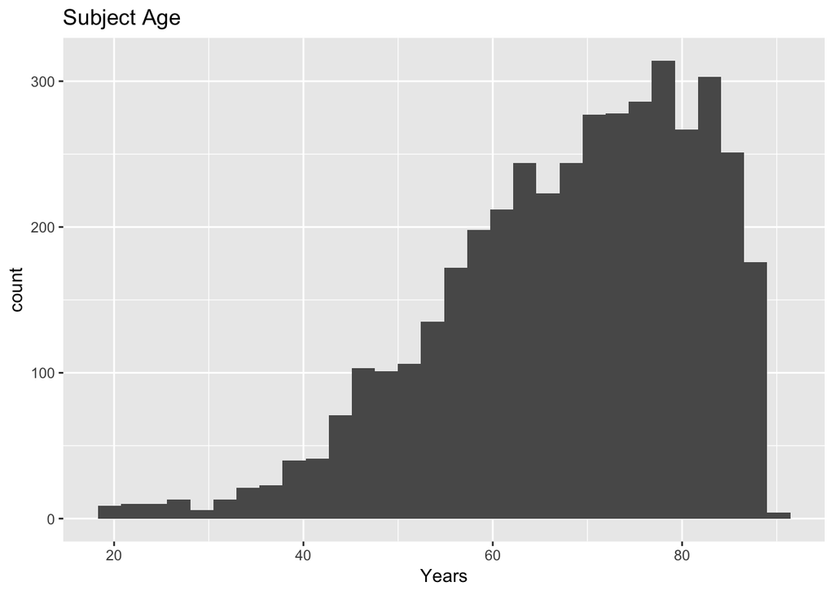

```r
sql <- sprintf(
       "SELECT *
        FROM [physionet-data.mimiciii_clinical.admissions] AS admissions
        JOIN [physionet-data.mimiciii_clinical.patients] AS patients
        ON admissions.subject_id = patients.subject_id
        WHERE admissions.hadm_id IN (%s)",
        paste(cohort$HADM_ID, collapse = ", "))

age.tbl <- query_exec(sql, project=project)
age.tbl$age <- difftime(age.tbl$admissions_ADMITTIME, age.tbl$patients_DOB, units='days')

age.tbl <- data.frame(age.tbl[, c('admissions_HADM_ID', 'age')])
colnames(age.tbl) <- c('HADM_ID', 'AGE')
cohort <- merge(cohort, age.tbl, by="HADM_ID")
cohort$AGE <- as.numeric(cohort$AGE) / 365

cohort <- cohort[cohort$AGE < 90 & cohort$AGE >= 18, ]

# Plot length of stay before removal
fig <- ggplot(cohort, aes(x=AGE)) +
  geom_histogram() +
  ggtitle('Subject Age') + xlab('Years')
print(fig)
```

The final cohort consists of 4151 encounters.

# Data extraction

```r
pull.last.event <- function(hadm_id, itemcodes, return.fields, table, project, max_pages=Inf) {
  sql <- sprintf("
                 SELECT *
                 FROM [physionet-data.mimiciii_clinical.%s] AS table1
                 INNER JOIN (
                   SELECT hadm_id, MAX(charttime), MAX(row_id)
                   FROM [physionet-data.mimiciii_clinical.%s]
                   WHERE itemid IN (%s)
                   AND hadm_id IN (%s)
                   GROUP BY hadm_id
                 ) AS table2
                 ON table1.row_id = table2.f1_",
                 table, table,
                 paste(itemcodes, collapse=", "),
                 paste(hadm_id, collapse=", ")
  )

  data <- query_exec(sql, project=project, max_pages=max_pages)
  colnames(data) <- gsub('table[0-9]_', '', colnames(data))
  return(data[ , return.fields])
}
```

## Systolic Blood Pressure

```r
sbp.itemcodes <- c( 6, 51, 442, 3313, 3315, 3317, 3321, 3323, 3325, 6701, 228152, 224167, 227243, 220050, 220179, 225309 )
return.fields <- c('SUBJECT_ID', 'HADM_ID', 'ITEMID', 'CHARTTIME', 'VALUENUM', 'VALUEUOM')
data.sbp <- pull.last.event(cohort$HADM_ID, sbp.itemcodes, return.fields, 'chartevents', project, max_pages=1)
```